# Instance-level Variable Attributions

這份講義主要說明如何使用 R 計算 Shapley values，針對個別資料研究解釋變數對預測值的貢獻度。以下三個例子皆以 tree-based models (Random Forest、XGBoost、LightGBM) 作為示範，建模的細節已很大程度地簡化，實用上還是建議善用交互驗證好好挑選模型參數。另外，事實上絕大多數的資料模型皆可用於 Shapley values 計算這類型的事後分析，並不限於 tree-based models，學員可自由替換模型來測試 Shapley values 計算出來的效果。

```r
install.packages(c("DALEX", "randomForest", "xgboost", "lightgbm", "ggplot2", "gridExtra"))
```

# 範例一：心臟疾病成因

資料為心臟疾病診斷結果與病患的檢驗報告數據，共有 303 位病患及 15 個欄位，以下是資料欄位的說明：

- `Unnamed: 0`: 編號（不重要，資料的索引代號）
- `Age`: 年齡（歲）
- `Sex`: 性別（`1` = 男性，`0` = 女性）
- `ChestPain` 胸痛類型（`typical`、`asymptomatic`、`nonanginal`、`nontypical`）
- `RestBP` 靜止血壓（mm Hg）
- `Chol`: 血清膽固醇濃度（mg/dl）
- `Fbs`: 空腹血糖 > 120 mg/dl（`1` = 是，`0` = 否）
- `RestECG`: 靜止心電圖結果（`0` = 正常、`1` = 有ST-T波異常、`2` = 左心室肥大）
- `MaxHR`: 運動心跳最大值
- `ExAng`: 運動誘發心絞痛（`1` = 有，`0` = 無）
- `Oldpeak`: 運動引起的 ST 段下降（和休息時比較，單位：mm）
- `Slope`: 運動高峰時 ST 段的坡度（`1` = 上升、`2` = 平坦、`3` = 下降）
- `Ca`: 螢光攝影檢測到的主要血管數量（`0` - `3`）
- `Thal`: 地中海貧血測試結果（`normal` = 正常、`fixed` = 固定缺陷、`reversable` = 可逆缺陷）
- `AHD`: 是否有心臟病（`Yes` = 有，`No` = 無）

```r
heartUrl <- 'https://raw.githubusercontent.com/PingYangChen/BDA_Course_R_Code/refs/heads/main/sample_data/Heart.csv'
heartDf <- read.csv(heartUrl)
heartDf$ChestPain <- as.factor(heartDf$ChestPain)
heartDf$Fbs <- as.factor(heartDf$Fbs)
heartDf$RestECG <- as.factor(heartDf$RestECG)
heartDf$ExAng <- as.factor(heartDf$ExAng)
heartDf$Slope <- as.factor(heartDf$Slope)
heartDf$Thal <- as.factor(heartDf$Thal)
heartDf$AHD <- as.factor(heartDf$AHD)
```

```r
# Remove the first Column: ID number
heartDf <- heartDf[,-1]
# Remove NAs
locNA <- which(sapply(1:nrow(heartDf), function(i) sum(is.na(heartDf[i,])) > 0))
heartDf <- heartDf[-locNA,]
```

```r
names(heartDf)
```

```
##  [1] "Age"       "Sex"       "ChestPain" "RestBP"    "Chol"      "Fbs"
##  [7] "RestECG"   "MaxHR"     "ExAng"     "Oldpeak"   "Slope"     "Ca"
## [13] "Thal"      "AHD"
```

```r
head(heartDf, 6)
```

```
##   Age Sex    ChestPain RestBP Chol Fbs RestECG MaxHR ExAng Oldpeak Slope Ca
## 1  63   1      typical    145  233   1       2   150     0     2.3     3  0
## 2  67   1 asymptomatic    160  286   0       2   108     1     1.5     2  3
## 3  67   1 asymptomatic    120  229   0       2   129     1     2.6     2  2
## 4  37   1   nonanginal    130  250   0       0   187     0     3.5     3  0
## 5  41   0   nontypical    130  204   0       2   172     0     1.4     1  0
## 6  56   1   nontypical    120  236   0       0   178     0     0.8     1  0
##         Thal AHD
## 1      fixed  No
## 2     normal Yes
## 3 reversable Yes
## 4     normal  No
## 5     normal  No
## 6     normal  No
```

```r
heartY <- as.numeric(heartDf$AHD) - 1
heartX <- heartDf[,-ncol(heartDf)]
```

```r
library(randomForest)
# Fit random forest model for the Heart data
heartRfMdl <- randomForest(x = heartX, y = as.factor(heartY), ntree = 100)
```

```r
# Create random forest explainer object
library(DALEX)
heartRfExp <- explain(heartRfMdl, data = heartX, y = heartY)
```

```
## Preparation of a new explainer is initiated
##   -> model label       :  randomForest  (  default  )
##   -> data              :  297  rows  13  cols
##   -> target variable   :  297  values
##   -> predict function  :  yhat.randomForest  will be used (  default  )
##   -> predicted values  :  No value for predict function target column. (  default  )
##   -> model_info        :  package randomForest , ver. 4.7.1.2 , task classification (  default  )
##   -> predicted values  :  numerical, min =  0 , mean =  0.4622559 , max =  1
##   -> residual function :  difference between y and yhat (  default  )
##   -> residuals         :  numerical, min =  -0.43 , mean =  -0.000976431 , max =  0.47
##   A new explainer has been created!
```

```r
# Return the fitted values for the first 10 observations
predict(heartRfMdl, newdata = heartX[1:10,])
```

```
##  1  2  3  4  5  6  7  8  9 10
##  0  1  1  0  0  0  1  0  1  1
## Levels: 0 1
```

```r
# Shapley value of observation 2
shapHeartObs_2 <- predict_parts(explainer = heartRfExp,
  new_observation = heartX[2,], type = "shap", B = 25
)
print(shapHeartObs_2)
```

```
##                                                 min            q1       median
## randomForest: Age = 67                 -0.036262626  1.246633e-02  0.027070707
## randomForest: Ca = 3                    0.080000000  1.271128e-01  0.141481481
## randomForest: ChestPain = asymptomatic  0.043299663  6.784512e-02  0.084467340
## randomForest: Chol = 286               -0.010505051  2.730640e-02  0.038215488
## randomForest: ExAng = 1                 0.014579125  3.835017e-02  0.049987879
## randomForest: Fbs = 0                  -0.001313131  7.575758e-05  0.001148148
## randomForest: MaxHR = 108               0.037070707  5.942761e-02  0.069983165
## randomForest: Oldpeak = 1.5            -0.015286195  2.441077e-03  0.013232323
## randomForest: RestBP = 160             -0.003569024  9.276094e-03  0.018181818
## randomForest: RestECG = 2              -0.011380471  6.734007e-03  0.010033670
## randomForest: Sex = 1                   0.002424242  1.616162e-02  0.020581818
## randomForest: Slope = 2                 0.027239057  3.771044e-02  0.044669360
## randomForest: Thal = normal            -0.080740741 -4.998316e-02 -0.026986532
##                                                mean          q3         max
## randomForest: Age = 67                  0.021236364 0.034840067 0.043097643
## randomForest: Ca = 3                    0.140148148 0.149124579 0.200909091
## randomForest: ChestPain = asymptomatic  0.083513805 0.099949495 0.117104377
## randomForest: Chol = 286                0.035543434 0.046102694 0.074949495
## randomForest: ExAng = 1                 0.050043098 0.063299663 0.081717172
## randomForest: Fbs = 0                   0.001218855 0.002356902 0.004242424
## randomForest: MaxHR = 108               0.077057239 0.092643098 0.133400673
## randomForest: Oldpeak = 1.5             0.015876094 0.028173401 0.053501684
## randomForest: RestBP = 160              0.025253872 0.045538721 0.070572391
## randomForest: RestECG = 2               0.010110438 0.014579125 0.022424242
## randomForest: Sex = 1                   0.020793266 0.024528620 0.035858586
## randomForest: Slope = 2                 0.045096296 0.053897306 0.063400673
## randomForest: Thal = normal            -0.028146801 0.003005051 0.011717172
```

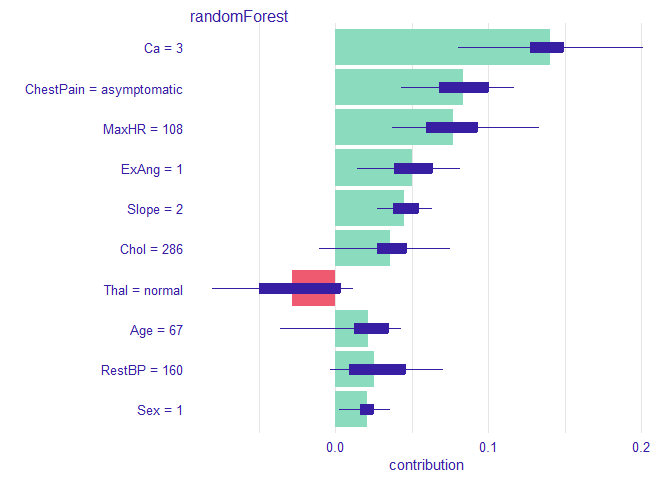

```r
# Draw the Shapley value of the second observation
plot(shapHeartObs_2)
```

```r
# Compute approximated Shapley value for the third observation
shapHeartObs_3 <- predict_parts(explainer = heartRfExp,
  new_observation = heartX[3,], type = "shap", B = 25
)
print(shapHeartObs_3)
```

```
##                                                  min           q1        median
## randomForest: Age = 67                 -0.0626599327 -0.006599327  0.0115488215
## randomForest: Ca = 2                    0.0691245791  0.107651515  0.1194612795
## randomForest: ChestPain = asymptomatic  0.0253198653  0.059368687  0.0703649832
## randomForest: Chol = 229               -0.0328282828 -0.014907407 -0.0104713805
## randomForest: ExAng = 1                 0.0044781145  0.026851852  0.0383501684
## randomForest: Fbs = 0                  -0.0006397306  0.000000000  0.0009878788
## randomForest: MaxHR = 129              -0.0221212121  0.009360269  0.0246821549
## randomForest: Oldpeak = 2.6             0.0603703704  0.081363636  0.0973191919
## randomForest: RestBP = 120             -0.0064309764  0.002037037  0.0114983165
## randomForest: RestECG = 2              -0.0049494949 -0.004040404  0.0034511785
## randomForest: Sex = 1                  -0.0124915825  0.009696970  0.0222336700
## randomForest: Slope = 2                 0.0146127946  0.029797980  0.0383212121
## randomForest: Thal = reversable         0.0349494949  0.051178451  0.0713468013
##                                                mean           q3         max
## randomForest: Age = 67                  0.009485522  0.031801347 0.040673401
## randomForest: Ca = 2                    0.124861953  0.136868687 0.194444444
## randomForest: ChestPain = asymptomatic  0.075140741  0.087811448 0.147878788
## randomForest: Chol = 229               -0.008817508 -0.001573064 0.013333333
## randomForest: ExAng = 1                 0.040562963  0.055867003 0.082491582
## randomForest: Fbs = 0                   0.001201347  0.002331650 0.003905724
## randomForest: MaxHR = 129               0.025189226  0.035824916 0.074242424
## randomForest: Oldpeak = 2.6             0.099453199  0.121077441 0.136329966
## randomForest: RestBP = 120              0.009224242  0.014898990 0.023804714
## randomForest: RestECG = 2               0.006226263  0.008762626 0.030202020
## randomForest: Sex = 1                   0.019955556  0.029612795 0.050000000
## randomForest: Slope = 2                 0.038999327  0.046885522 0.067205387
## randomForest: Thal = reversable         0.076261279  0.100740741 0.154680135
```

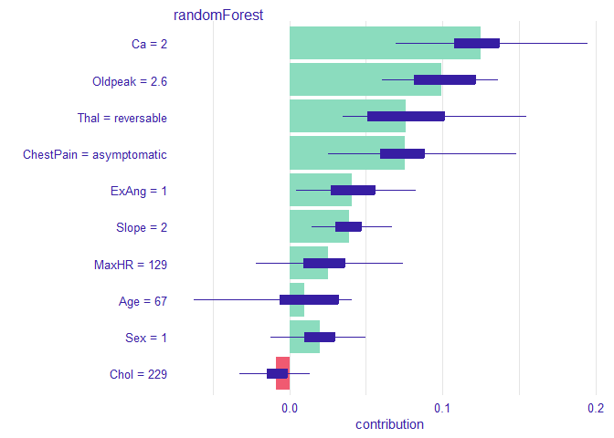

```r
# Draw the Shapley value of the first observation
plot(shapHeartObs_3)
```

# 範例二：員工離職動機

此資料描述員工的基本資料、工作情況、與職場問卷調查分數，欲分析員工離職的可能性以及影響離職的關鍵因素，以下是資料欄位的說明：

- `Attrition`: 員工是否離職（“Yes” 表示離職，“No” 表示未離職）為反應變數。
- `Age`: 員工年齡。
- `Gender`: 員工性別。
- `TotalWorkingYears`: 總工作年數。
- `YearsInCurrentRole`: 在當前職位上的工作年數。
- `YearsSinceLastPromotion`: 自上次晉升以來的年數。
- `DistanceFromHome`: 通勤距離。
- `JobLevel`: 職位等級。
- `MonthlyIncome`: 每月收入。
- `PercentSalaryHike`: 薪資漲幅百分比。
- `TrainingTimesLastYear`: 去年接受培訓的次數。
- `StockOptionLevel`: 股票期權等級。
- `EnvironmentSatisfaction`: 對工作環境的滿意度（數值表示，`1`-`4`）。
- `JobInvolvement`: 工作參與度（數值表示，`1`-`4`）。
- `JobSatisfaction`: 對工作的滿意度（數值表示，`1`-`4`）。
- `RelationshipSatisfaction`: 與同事或上司的關係滿意度（數值表示，`1`-`4`）。
- `WorkLifeBalance`: 工作與生活的平衡程度（數值表示，`1`-`4`）。

```r
AttrUrl <- 'https://raw.githubusercontent.com/PingYangChen/BDA_Course_R_Code/refs/heads/main/sample_data/attrition.csv'
AttrDf <- read.csv(AttrUrl)
AttrDf$Attrition <- as.factor(AttrDf$Attrition)
AttrDf$Gender <- as.factor(AttrDf$Gender)
```

```r
names(AttrDf)
```

```
##  [1] "Attrition"                "Age"
##  [3] "Gender"                   "TotalWorkingYears"
##  [5] "YearsInCurrentRole"       "YearsSinceLastPromotion"
##  [7] "DistanceFromHome"         "JobLevel"
##  [9] "MonthlyIncome"            "PercentSalaryHike"
## [11] "TrainingTimesLastYear"    "StockOptionLevel"
## [13] "EnvironmentSatisfaction"  "JobInvolvement"
## [15] "JobSatisfaction"          "RelationshipSatisfaction"
## [17] "WorkLifeBalance"
```

```r
head(AttrDf, 6)
```

```
##   Attrition Age Gender TotalWorkingYears YearsInCurrentRole
## 1       Yes  41 Female                 8                  4
## 2        No  49   Male                10                  7
## 3       Yes  37   Male                 7                  0
## 4        No  33 Female                 8                  7
## 5        No  27   Male                 6                  2
## 6        No  32   Male                 8                  7
##   YearsSinceLastPromotion DistanceFromHome JobLevel MonthlyIncome
## 1                       0                1        2          5993
## 2                       1                8        2          5130
## 3                       0                2        1          2090
## 4                       3                3        1          2909
## 5                       2                2        1          3468
## 6                       3                2        1          3068
##   PercentSalaryHike TrainingTimesLastYear StockOptionLevel
```

[output cut: 20 more lines]

```r
AttrY <- as.numeric(AttrDf$Attrition) - 1
AttrX <- model.matrix(~ ., data = AttrDf[,-1])[,-1]
#
AttrY_Distri <- table(AttrY)/sum(table(AttrY))
AttrW <- (1/AttrY_Distri[1])^AttrY * (1/AttrY_Distri[2])^(1 - AttrY)
```

```r
library(xgboost)
attrXgbMdl <- xgboost(
  data = AttrX, label = AttrY, nrounds = 20, weight = AttrW, verbose = FALSE,
  params = list(max.depth = 3, eta = 0.1, objective = "binary:logistic")
)
```

```r
# Create xgboost explainer object
library(DALEX)
attrXgbExp <- explain(attrXgbMdl, data = AttrX, y = AttrY)
```

```
## Preparation of a new explainer is initiated
##   -> model label       :  xgb.Booster  (  default  )
##   -> data              :  1470  rows  16  cols
##   -> target variable   :  1470  values
##   -> predict function  :  yhat.default will be used (  default  )
##   -> predicted values  :  No value for predict function target column. (  default  )
##   -> model_info        :  package Model of class: xgb.Booster package unrecognized , ver. Unknown , task regression (  default  )
##   -> predicted values  :  numerical, min =  0.07754879 , mean =  0.1040807 , max =  0.7704924
##   -> residual function :  difference between y and yhat (  default  )
##   -> residuals         :  numerical, min =  -0.3114927 , mean =  0.0571438 , max =  0.9224512
##   A new explainer has been created!
```

```r
# Return the fitted values for the 1st observation
attrXgbPred <- predict(attrXgbMdl, newdata = as.matrix(AttrX))
```

```r
# Shapley value of observation 1
shapAttrObs_1 <- predict_parts(explainer = attrXgbExp,
  new_observation = t(as.matrix(AttrX[1,])), type = "shap", B = 25
)
print(shapAttrObs_1)
```

```
##                                                     min            q1
## xgb.Booster: Age = 41                     -4.911705e-03 -3.341491e-03
## xgb.Booster: DistanceFromHome = 1         -8.571287e-03 -4.870456e-03
## xgb.Booster: EnvironmentSatisfaction = 2  -1.710766e-03 -7.470229e-04
## xgb.Booster: GenderMale = 0                0.000000e+00  0.000000e+00
## xgb.Booster: JobInvolvement = 3           -3.440211e-03 -2.482250e-03
## xgb.Booster: JobLevel = 2                 -1.550178e-02 -1.231357e-02
## xgb.Booster: JobSatisfaction = 4          -1.524704e-03 -9.051907e-04
## xgb.Booster: MonthlyIncome = 5993         -9.366888e-03 -6.648022e-03
## xgb.Booster: PercentSalaryHike = 11       -1.610513e-03 -7.589833e-04
## xgb.Booster: RelationshipSatisfaction = 1  0.000000e+00  0.000000e+00
## xgb.Booster: StockOptionLevel = 0          6.309119e-03  7.919263e-03
## xgb.Booster: TotalWorkingYears = 8        -7.991150e-03 -6.668588e-03
## xgb.Booster: TrainingTimesLastYear = 0     0.000000e+00  0.000000e+00
## xgb.Booster: WorkLifeBalance = 1           2.501298e-03  6.026228e-03
## xgb.Booster: YearsInCurrentRole = 4        0.000000e+00  0.000000e+00
## xgb.Booster: YearsSinceLastPromotion = 0  -9.344232e-05 -6.913383e-05
##                                                  median          mean
## xgb.Booster: Age = 41                     -2.409223e-03 -2.489662e-03
## xgb.Booster: DistanceFromHome = 1         -4.654495e-03 -4.356635e-03
## xgb.Booster: EnvironmentSatisfaction = 2  -9.394889e-05 -5.179479e-05
## xgb.Booster: GenderMale = 0                0.000000e+00  0.000000e+00
## xgb.Booster: JobInvolvement = 3           -1.969059e-03 -2.141657e-03
## xgb.Booster: JobLevel = 2                 -1.068754e-02 -9.660984e-03
## xgb.Booster: JobSatisfaction = 4          -5.737982e-04 -6.893793e-04
## xgb.Booster: MonthlyIncome = 5993         -5.105087e-03 -5.053610e-03
## xgb.Booster: PercentSalaryHike = 11        0.000000e+00 -5.093796e-04
## xgb.Booster: RelationshipSatisfaction = 1  5.943398e-04  4.303902e-04
## xgb.Booster: StockOptionLevel = 0          9.564040e-03  9.488421e-03
## xgb.Booster: TotalWorkingYears = 8        -4.113954e-03 -4.319242e-03
## xgb.Booster: TrainingTimesLastYear = 0     0.000000e+00  1.326378e-04
## xgb.Booster: WorkLifeBalance = 1           9.449174e-03  8.803989e-03
## xgb.Booster: YearsInCurrentRole = 4        0.000000e+00  0.000000e+00
## xgb.Booster: YearsSinceLastPromotion = 0   0.000000e+00 -2.449622e-05
##                                                      q3           max
## xgb.Booster: Age = 41                     -1.608503e-03 -0.0007630406
## xgb.Booster: DistanceFromHome = 1         -3.348255e-03 -0.0013605580
## xgb.Booster: EnvironmentSatisfaction = 2   6.028619e-04  0.0015651005
## xgb.Booster: GenderMale = 0                0.000000e+00  0.0000000000
## xgb.Booster: JobInvolvement = 3           -1.775196e-03 -0.0009758340
## xgb.Booster: JobLevel = 2                 -6.563819e-03 -0.0037336263
## xgb.Booster: JobSatisfaction = 4          -4.785101e-04 -0.0002024742
## xgb.Booster: MonthlyIncome = 5993         -3.370098e-03 -0.0029463035
## xgb.Booster: PercentSalaryHike = 11        0.000000e+00  0.0000000000
## xgb.Booster: RelationshipSatisfaction = 1  7.925780e-04  0.0008915391
## xgb.Booster: StockOptionLevel = 0          1.119636e-02  0.0119540238
## xgb.Booster: TotalWorkingYears = 8        -2.327173e-03 -0.0009749414
## xgb.Booster: TrainingTimesLastYear = 0     9.947836e-05  0.0006109708
## xgb.Booster: WorkLifeBalance = 1           1.198208e-02  0.0152049844
## xgb.Booster: YearsInCurrentRole = 4        0.000000e+00  0.0000000000
## xgb.Booster: YearsSinceLastPromotion = 0   0.000000e+00  0.0000000000
```

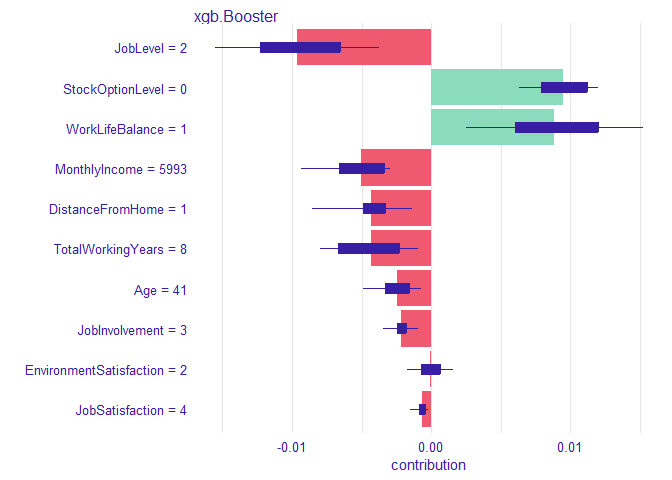

```r
# Draw the Shapley value of observation 1
plot(shapAttrObs_1)
```

```r
attrXgbPredId_Yes <- which(attrXgbPred > 0.5)
print(attrXgbPredId_Yes)
```

```
##  [1]   43  128  464  684  689  798  912 1223 1333 1366
```

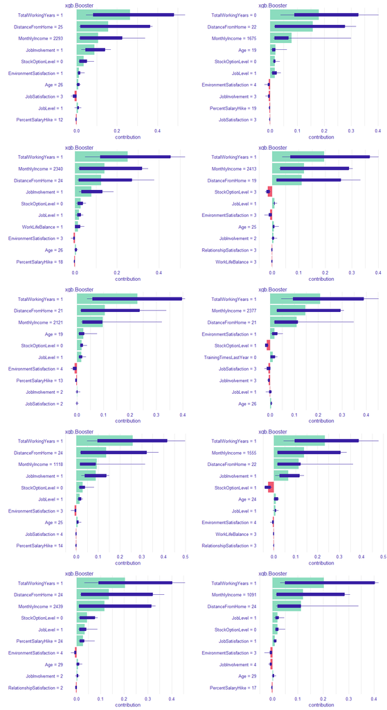

```r
# Compute approximated Shapley value for observations with prediction Attrition = Yes
library(ggplot2)
library(gridExtra)

nShpPlots <- length(attrXgbPredId_Yes)
nShpCol <- 2
nShpRow <- ceiling(nShpPlots/nShpCol)

gplotList <- vector(mode = "list", length = nShpPlots)
for (i in 1:nShpPlots) {
  shapAttrObs <- predict_parts(explainer = attrXgbExp,
    new_observation = t(as.matrix(AttrX[attrXgbPredId_Yes[i],])), type = "shap", B = 25
  )
  gplotList[[i]] <- plot(shapAttrObs)
}
grid.arrange(grobs=gplotList, nrow = nShpRow)
```

# 範例三：房價構成要素

此資料集描述房地產相關的特性與價格，包含以下欄位：

- `price`: 房屋價格（貨幣單位表示）
- `area`: 房屋面積（平方英尺）
- `bedrooms`: 臥室數量
- `bathrooms`: 浴室數量
- `stories`: 層數
- `mainroad`: 是否臨主路（`"yes"` 表示是，`"no"` 表示否）
- `guestroom`: 是否有客房（`"yes"` 表示有，`"no"` 表示沒有）
- `basement`: 是否有地下室（`"yes"` 表示有，`"no"` 表示沒有）
- `hotwaterheating`: 是否有熱水供暖系統（`"yes"` 表示有，`"no"` 表示沒有）
- `airconditioning`: 是否有空調（`"yes"` 表示有，`"no"` 表示沒有）
- `parking`: 車位數量
- `prefarea`: 是否位於首選地區（`"yes"` 表示是，`"no"` 表示否）
- `furnishingstatus`: 家具狀態（`"furnished"` 表示全配家具，`"semi-furnished"` 表示部分家具，`"unfurnished"` 表示無家具）

```r
HouseUrl <- 'https://raw.githubusercontent.com/PingYangChen/BDA_Course_R_Code/refs/heads/main/sample_data/housing.csv'
HouseDf <- read.csv(HouseUrl)
HouseDf$mainroad <- as.factor(HouseDf$mainroad)
HouseDf$guestroom <- as.factor(HouseDf$guestroom)
HouseDf$basement <- as.factor(HouseDf$basement)
HouseDf$hotwaterheating <- as.factor(HouseDf$hotwaterheating)
HouseDf$airconditioning <- as.factor(HouseDf$airconditioning)
HouseDf$prefarea <- as.factor(HouseDf$prefarea)
HouseDf$furnishingstatus <- as.factor(HouseDf$furnishingstatus)
```

```r
names(HouseDf)
```

```
##  [1] "price"            "area"             "bedrooms"         "bathrooms"
##  [5] "stories"          "mainroad"         "guestroom"        "basement"
##  [9] "hotwaterheating"  "airconditioning"  "parking"          "prefarea"
## [13] "furnishingstatus"
```

```r
head(HouseDf, 6)
```

```
##      price area bedrooms bathrooms stories mainroad guestroom basement
## 1 13300000 7420        4         2       3      yes        no       no
## 2 12250000 8960        4         4       4      yes        no       no
## 3 12250000 9960        3         2       2      yes        no      yes
## 4 12215000 7500        4         2       2      yes        no      yes
## 5 11410000 7420        4         1       2      yes       yes      yes
## 6 10850000 7500        3         3       1      yes        no      yes
##   hotwaterheating airconditioning parking prefarea furnishingstatus
## 1              no             yes       2      yes        furnished
## 2              no             yes       3       no        furnished
## 3              no              no       2      yes   semi-furnished
## 4              no             yes       3      yes        furnished
## 5              no             yes       2       no        furnished
## 6              no             yes       2      yes   semi-furnished
```

```r
HouseY <- HouseDf$price
HouseX <- model.matrix(~ ., data = HouseDf[,-1])[,-1]
```

```r
library(lightgbm)
houseLgbmMdl <- lightgbm(
  data = HouseX, label = HouseY, nrounds = 5,
  params = list(max.depth = 2, learning_rate = 0.5, objective = "regression",
                bagging_freq = 1)
)
```

```
## [LightGBM] [Info] Auto-choosing row-wise multi-threading, the overhead of testing was 0.000799 seconds.
## You can set `force_row_wise=true` to remove the overhead.
## And if memory is not enough, you can set `force_col_wise=true`.
## [LightGBM] [Info] Total Bins 215
## [LightGBM] [Info] Number of data points in the train set: 545, number of used features: 13
## [LightGBM] [Info] Start training from score 4766729.247706
```

從模型檢視影響房價的前三大關鍵因子

```r
# Create xgboost explainer object
library(DALEX)
houseLgbmExp <- explain(houseLgbmMdl, data = HouseX, y = HouseY)
```

```
## Preparation of a new explainer is initiated
##   -> model label       :  R6  (  default  )
##   -> data              :  545  rows  13  cols
##   -> target variable   :  545  values
##   -> predict function  :  yhat.default will be used (  default  )
##   -> predicted values  :  No value for predict function target column. (  default  )
##   -> model_info        :  package Model of class: lgb.Booster package unrecognized , ver. Unknown , task regression (  default  )
##   -> predicted values  :  numerical, min =  2938428 , mean =  4766729 , max =  7809179
##   -> residual function :  difference between y and yhat (  default  )
##   -> residuals         :  numerical, min =  -2580928 , mean =  0.001164008 , max =  5490821
##   A new explainer has been created!
```

```r
houseLgbmVarImp <- model_parts(houseLgbmExp, type = "variable_importance")
print(houseLgbmVarImp)
```

```
##                          variable mean_dropout_loss label
## 1                    _full_model_           1139846    R6
## 2                    guestroomyes           1139846    R6
## 3              hotwaterheatingyes           1139846    R6
## 4  furnishingstatussemi-furnished           1139846    R6
## 5                     basementyes           1145770    R6
## 6     furnishingstatusunfurnished           1158595    R6
## 7                     mainroadyes           1164809    R6
## 8                         stories           1179850    R6
## 9                     prefareayes           1182529    R6
## 10                       bedrooms           1192121    R6
## 11                        parking           1206203    R6
## 12             airconditioningyes           1242997    R6
## 13                      bathrooms           1360410    R6
## 14                           area           1491787    R6
## 15                     _baseline_           2242214    R6
```

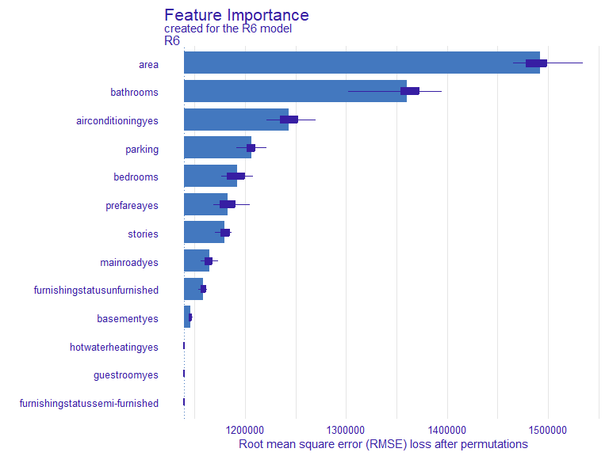

```r
plot(houseLgbmVarImp)
```

以下 `HouseTestDf` 資料，此三筆資料的 `'area'` 皆一樣大，利用模型預測房價，並個別解析三者房價不同的原因。

```r
HouseTestDf <- data.frame(
  'area'= c(6000, 6000, 6000), 'bedrooms'= c(4, 4, 2), 'bathrooms'= c(3, 2, 1),
  'stories'= c(2, 4, 1), 'mainroad' = c('yes', 'yes', 'yes'),
  'guestroom' = c('yes', 'no', 'no'), 'basement' = c('yes', 'no', 'no'),
  'hotwaterheating' = c('yes', 'no', 'no'), 'airconditioning' =  c('yes', 'yes', 'no'),
  'parking' = c(2, 0, 0), 'prefarea' = c('no', 'no', 'no'),
  'furnishingstatus' = c('semi-furnished', 'unfurnished', 'semi-furnished')
)
print(HouseTestDf)
```

```
##   area bedrooms bathrooms stories mainroad guestroom basement hotwaterheating
## 1 6000        4         3       2      yes       yes      yes             yes
## 2 6000        4         2       4      yes        no       no              no
## 3 6000        2         1       1      yes        no       no              no
##   airconditioning parking prefarea furnishingstatus
## 1             yes       2       no   semi-furnished
## 2             yes       0       no      unfurnished
## 3              no       0       no   semi-furnished
```

```r
HouseTestDf$mainroad  <- factor(HouseTestDf$mainroad, levels = levels(HouseDf$mainroad))
HouseTestDf$guestroom <- factor(HouseTestDf$guestroom, levels = levels(HouseDf$guestroom))
HouseTestDf$basement  <- factor(HouseTestDf$basement, levels = levels(HouseDf$basement))
HouseTestDf$hotwaterheating  <- factor(HouseTestDf$hotwaterheating, levels = levels(HouseDf$hotwaterheating))
HouseTestDf$airconditioning  <- factor(HouseTestDf$airconditioning, levels = levels(HouseDf$airconditioning))
HouseTestDf$prefarea         <- factor(HouseTestDf$prefarea, levels = levels(HouseDf$prefarea))
HouseTestDf$furnishingstatus <- factor(HouseTestDf$furnishingstatus, levels = levels(HouseDf$furnishingstatus))
```

```r
# Return the fitted values for the 1st observation
HouseTestX <- model.matrix(~ ., data = HouseTestDf)[,-1]
houseLgbmPred <- predict(houseLgbmMdl, newdata = HouseTestX)
print(houseLgbmPred)
```

```
##       1       2       3
## 7201070 6912126 4800390
```

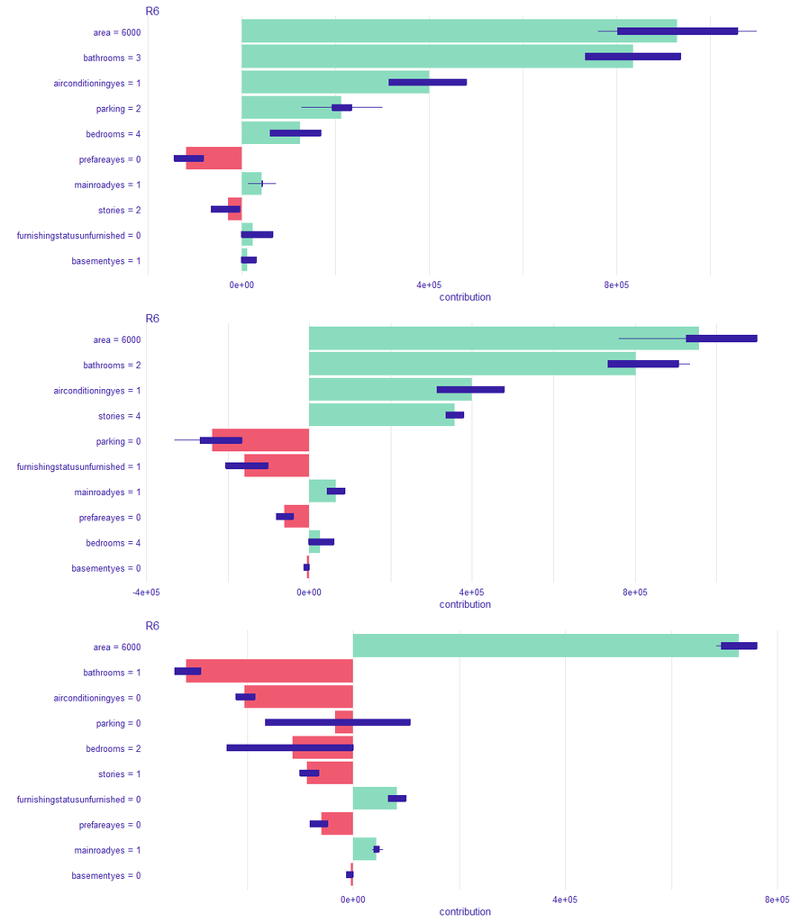

```r
# Compute approximated Shapley value for observations with prediction Attrition = Yes
library(ggplot2)
library(gridExtra)

nShpPlots <- length(houseLgbmPred)
nShpCol <- 1
nShpRow <- ceiling(nShpPlots/nShpCol)

gplotList <- vector(mode = "list", length = nShpPlots)
for (i in 1:nShpPlots) {
  shapHouseObs <- predict_parts(explainer = houseLgbmExp,
    new_observation = t(as.matrix(HouseTestX[i,])), type = "shap", B = 25
  )
  gplotList[[i]] <- plot(shapHouseObs)
}
grid.arrange(grobs=gplotList, nrow = nShpRow)
```